```r
options(OutDec = ".")  # Asegurar punto decimal en este chunk

# Establecer semilla aleatoria
set.seed(sample(1:10000, 1))

# Aleatorizar dimensiones del parabrisas (largo)
largo_base <- sample(c(12, 13, 14, 15, 16, 18), 1)
# Aleatorizar dimensiones del parabrisas (ancho)
ancho_base <- sample(c(6, 7, 8, 9, 10), 1)

# Aleatorizar longitud de las plumillas
longitud_plumillas <- sample(c(5, 6, 7), 1)

# Aleatorizar ángulo de apertura
angulo_apertura <- sample(c(75, 80, 85, 90, 95), 1)

# Aleatorizar terminología
objetos <- c(
  "parabrisas", "vidrio frontal", "cristal delantero", "ventana frontal",
  "luna delantera", "visor frontal"
)
objeto <- sample(objetos, 1)

vehiculos <- c(
  "carrito de juguete", "automóvil de juguete", "miniatura de vehículo",
  "modelo a escala", "juguete de coche", "vehículo a escala",
  "juguete de transporte", "modelo de automóvil"
)
vehiculo <- sample(vehiculos, 1)

dispositivos <- c(
  "plumillas", "limpiaparabrisas", "limpiacristales", "limpiadores",
  "escobillas", "limpiadores de cristal"
)
dispositivo <- sample(dispositivos, 1)

verbos_limpieza <- c(
  "limpiar", "despejar", "eliminar suciedad de", "desempañar",
  "mantener limpio", "quitar impurezas de"
)
verbo_limpieza <- sample(verbos_limpieza, 1)

formas_geometricas <- c(
  "plano y de forma rectangular", "plano con forma de rectángulo",
  "rectangular y de superficie plana", "con forma de rectángulo plano",
  "de estructura rectangular plana"
)
forma_geometrica <- sample(formas_geometricas, 1)

# Verificar que longitud_plumillas <= largo_base/2 para asegurar que las plumillas caben
if (longitud_plumillas > largo_base/2) {
  longitud_plumillas <- floor(largo_base/2)
}

# Función para crear distractores definidos explícitamente (no aleatorios)
crear_distractor_garantizado <- function(valor_correcto) {
  posibles_distractores <- c(
    valor_correcto - 2,
    valor_correcto - 1,
    valor_correcto + 1,
    valor_correcto + 2
  )
  # Filtrar valores negativos o cero
  posibles_distractores <- posibles_distractores[posibles_distractores > 0]
  # Seleccionar un distractor
  distractor <- sample(posibles_distractores, 1)
  return(distractor)
}

# Generar distractores para las plumillas de forma garantizada
plumilla_distractor1 <- crear_distractor_garantizado(longitud_plumillas)
# Asegurar que plumilla_distractor2 es diferente de plumilla_distractor1 y longitud_plumillas
repeat {
  plumilla_distractor2 <- crear_distractor_garantizado(longitud_plumillas)
  if (plumilla_distractor2 != plumilla_distractor1 &&
      plumilla_distractor2 != longitud_plumillas) {
    break
  }
}

# Generar distractores sutiles para el largo de forma garantizada
largo_distractor <- crear_distractor_garantizado(largo_base)
# Asegurar que largo_distractor es diferente de largo_base
while(largo_distractor == largo_base) {
  largo_distractor <- crear_distractor_garantizado(largo_base)
}

# Generar distractores sutiles para el ancho de forma garantizada
ancho_distractor <- crear_distractor_garantizado(ancho_base)
# Asegurar que ancho_distractor es diferente de ancho_base
while(ancho_distractor == ancho_base) {
  ancho_distractor <- crear_distractor_garantizado(ancho_base)
}

# Crear opciones con distractores sutiles
# La diferencia clave está en que algunos distractores intercambian valores o
# introducen errores sutiles en las medidas

# Opción A: Longitudes correctas, plumillas incorrectas (intercambiadas con largo)
opcion_A <- list(
  largo = largo_base,
  ancho = ancho_base,
  plumilla1 = plumilla_distractor1,  # Error sutil
  plumilla2 = plumilla_distractor1   # Mantener simetría
)

# Opción B: Primera plumilla correcta, segunda incorrecta (valores similares pero incorrectos)
opcion_B <- list(
  largo = largo_base,
  ancho = ancho_base,
  plumilla1 = longitud_plumillas,
  plumilla2 = plumilla_distractor2   # Asimetría sutil pero plausible
)

# Opción C: Dimensiones correctas, ambas plumillas correctas (ESTA ES LA CORRECTA)
opcion_C <- list(
  largo = largo_base,
  ancho = ancho_base,
  plumilla1 = longitud_plumillas,
  plumilla2 = longitud_plumillas
)

# Opción D: Dimensiones incorrectas sutilmente, plumillas correctas
opcion_D <- list(
  largo = largo_distractor,
  ancho = ancho_distractor,
  plumilla1 = longitud_plumillas,
  plumilla2 = longitud_plumillas
)

# Especificamos que la opción C es la correcta
posicion_correcta <- 3
solucion <- c(0, 0, 1, 0)

# Aleatorizar posición de la opción correcta
if (runif(1) > 0.5) {  # 50% de probabilidad de reordenar
  nuevo_orden <- sample(1:4, 4)
  opciones <- list(opcion_A, opcion_B, opcion_C, opcion_D)
  opciones_reordenadas <- opciones[nuevo_orden]
  opcion_A <- opciones_reordenadas[[1]]
  opcion_B <- opciones_reordenadas[[2]]
  opcion_C <- opciones_reordenadas[[3]]
  opcion_D <- opciones_reordenadas[[4]]

  # Actualizar la posición correcta y solución
  posicion_correcta <- which(nuevo_orden == 3)
  solucion <- rep(0, 4)
  solucion[posicion_correcta] <- 1
}

# Aleatorizar colores (pero mantener coherencia visual)
colores_disponibles <- c("red", "blue", "green", "purple", "orange", "brown", "magenta", "teal")
color_linea_principal <- sample(colores_disponibles, 1)
colores_disponibles <- colores_disponibles[colores_disponibles != color_linea_principal]
color_rect <- sample(colores_disponibles, 1)
colores_disponibles <- colores_disponibles[colores_disponibles != color_rect]
color_texto <- sample(colores_disponibles, 1)
colores_disponibles <- colores_disponibles[colores_disponibles != color_texto]
color_plumilla <- sample(colores_disponibles, 1)

# Propiedades gráficas
intensidad_color <- sample(c(70, 80, 90), 1)
grosor_linea <- sample(c(1.2, 1.5, 1.8), 1)
grosor_plumilla <- sample(c(1.5, 2.0), 1)

# Aleatorizar estilos de línea para variedad visual pero mantener consistencia
# para evitar que estas características revelen la respuesta
estilo_linea_principal <- "solid"  # Mantener consistente para no dar pistas
estilo_rect <- "solid"  # Mantener consistente para no dar pistas
```

```r
# Función para verificar coherencia matemática y que los distractores sean adecuados
validar_datos <- function() {
  # Verificar que las dimensiones tienen sentido
  test_that("Dimensiones coherentes", {
    expect_true(largo_base > 0)
    expect_true(ancho_base > 0)
    expect_true(longitud_plumillas > 0)
    expect_true(angulo_apertura > 0)

    # Verificar que las dimensiones de las plumillas son coherentes con el parabrisas
    expect_true(longitud_plumillas <= largo_base / 2,
                info = "Las plumillas no pueden ser más largas que la mitad del parabrisas")

    # Verificar que los distractores son diferentes de los valores correctos
    expect_false(plumilla_distractor1 == longitud_plumillas,
                 info = "El distractor 1 no puede tener el mismo valor que la plumilla correcta")
    expect_false(plumilla_distractor2 == longitud_plumillas,
                 info = "El distractor 2 no puede tener el mismo valor que la plumilla correcta")
    expect_false(ancho_distractor == ancho_base,
                 info = "El distractor de ancho no puede ser igual al correcto")
    expect_false(largo_distractor == largo_base,
                 info = "El distractor de largo no puede ser igual al correcto")

    # Verificar que las opciones son diferentes entre sí
    expect_false(identical(opcion_A, opcion_B),
                 info = "Las opciones A y B no pueden ser idénticas")
    expect_false(identical(opcion_A, opcion_C),
                 info = "Las opciones A y C no pueden ser idénticas")
    expect_false(identical(opcion_A, opcion_D),
                 info = "Las opciones A y D no pueden ser idénticas")
    expect_false(identical(opcion_B, opcion_C),
                 info = "Las opciones B y C no pueden ser idénticas")
    expect_false(identical(opcion_B, opcion_D),
                 info = "Las opciones B y D no pueden ser idénticas")
    expect_false(identical(opcion_C, opcion_D),
                 info = "Las opciones C y D no pueden ser idénticas")
  })

  return(TRUE)
}

# Ejecutar la validación
validacion_exitosa <- validar_datos()
```

```
## Test passed 🥇
```

```r
options(OutDec = ".")  # Asegurar punto decimal en este chunk

# Código Python para el diagrama principal con plumillas
codigo_python_diagrama_principal <- sprintf('
import matplotlib.pyplot as plt
import numpy as np

fig, ax = plt.subplots(figsize=(8, 4))

# Rectángulo punteado
rect_x = [0.5, %.1f, %.1f, 0.5, 0.5]
rect_y = [0, 0, 3, 3, 0]
ax.plot(rect_x, rect_y, linestyle="dashed", color="gray", dashes=(4, 4))

def dibujar_abanico(x_origin, y_origin, radius, lines_count=5, angulo=%.1f):
    # Conversión a radianes
    angulo_rad = (angulo * np.pi) / 180

    # Arco punteado
    theta = np.linspace(0, angulo_rad, 100)
    ax.plot(x_origin + radius * np.cos(theta), y_origin + radius * np.sin(theta),
            color="gray", linestyle="dashed", dashes=(4,4))

    # Líneas radiales
    for i in range(lines_count):
        angle = angulo_rad * i / (lines_count - 1)
        x_end = x_origin + radius * np.cos(angle)
        y_end = y_origin + radius * np.sin(angle)

        if i == 0 or i == 3:
            linewidth = %.1f
            ax.plot([x_origin, x_end], [y_origin, y_end], color="black", linewidth=linewidth)
        else:
            ax.plot([x_origin, x_end], [y_origin, y_end],
                    color="gray", linestyle="dashed", dashes=(4,4), linewidth=0.8)

# Posición de los abanicos
distancia_entre_abanicos = %.1f
dibujar_abanico(1.2, 0, %.1f, lines_count=5, angulo=%.1f)
dibujar_abanico(1.2 + distancia_entre_abanicos, 0, %.1f, lines_count=5, angulo=%.1f)

# Ajustar la posición de la flecha y texto "%s"
ax.annotate("%s", xy=(1.7, 1.7), xytext=(0.5, 1.5),
            arrowprops=dict(facecolor="black", arrowstyle="->", linewidth=1),
            fontsize=10, ha="right", va="center")

# Ajustes de gráficos
ax.set_aspect("equal")
ax.axis("off")
plt.xlim(0, 7.5)
plt.ylim(-0.6, 3.5)

plt.tight_layout()
plt.savefig("diagrama_principal.png", dpi=150, bbox_inches="tight")
plt.close()
',
6.7, 6.7,
angulo_apertura,
grosor_plumilla,
2.75,
longitud_plumillas, angulo_apertura,
longitud_plumillas, angulo_apertura,
dispositivo, dispositivo)
```

```r
options(OutDec = ".")  # Asegurar punto decimal en este chunk

# Función para generar esquemas según diferentes dimensiones
# Esta función usa un estilo y estructura consistente para todas las opciones
# para que no se pueda identificar la respuesta correcta por el estilo visual
generar_codigo_esquema <- function(ancho, alto, ancho_plumilla1, ancho_plumilla2,
                                  color_principal = color_linea_principal,
                                  etiqueta = "") {
    # Ajustar proporciones para la visualización
    factor_escala <- 10
    ancho_escalado <- ancho / factor_escala
    alto_escalado <- alto / factor_escala
    ancho_plumilla1_escalado <- ancho_plumilla1 / factor_escala
    ancho_plumilla2_escalado <- ancho_plumilla2 / factor_escala

    # Multiplicar por 2 para dejar espacio adecuado
    margin_factor <- 2

    codigo <- sprintf('
import matplotlib.pyplot as plt
import numpy as np

fig, ax = plt.subplots(figsize=(6, 6))

# Dimensiones
ancho_parabrisas = %.2f
alto_parabrisas = %.2f
ancho_plumilla1 = %.2f
ancho_plumilla2 = %.2f

# Dibujar el rectángulo principal
rect_x = [0, ancho_parabrisas, ancho_parabrisas, 0, 0]
rect_y = [0, 0, alto_parabrisas, alto_parabrisas, 0]
ax.plot(rect_x, rect_y, color="%s", linewidth=%.1f)

# Calcular radio para los arcos (debe ser igual al ancho de las plumillas)
radio1 = ancho_plumilla1
radio2 = ancho_plumilla2

# Función para dibujar arcos de 90 grados
def dibujar_arco_90(x_centro, y_centro, radio):
    theta = np.linspace(0, np.pi/2, 100)
    x = x_centro + radio * np.cos(theta)
    y = y_centro + radio * np.sin(theta)
    ax.plot(x, y, color="%s", linewidth=%.1f)

    # Dibujar líneas de referencia (horizontal y vertical)
    ax.plot([x_centro, x_centro + radio], [y_centro, y_centro], color="%s", linewidth=%.1f)
    ax.plot([x_centro, x_centro], [y_centro, y_centro + radio], color="%s", linewidth=%.1f)

# Dibujar arco 1 (izquierda)
dibujar_arco_90(0, 0, radio1)

# Dibujar arco 2 (derecha)
dibujar_arco_90(ancho_parabrisas - radio2, 0, radio2)

# Añadir dimensiones con flechas y texto
# Dimensión horizontal superior (ancho total)
ax.annotate("", xy=(0, alto_parabrisas + 0.2), xytext=(ancho_parabrisas, alto_parabrisas + 0.2),
            arrowprops=dict(arrowstyle="<->", color="%s", linewidth=%.1f))
ax.text(ancho_parabrisas/2, alto_parabrisas + 0.4, "%d cm",
        ha="center", va="center", color="%s", fontsize=12)

# Dimensión vertical izquierda (altura)
ax.annotate("", xy=(-0.2, 0), xytext=(-0.2, alto_parabrisas),
            arrowprops=dict(arrowstyle="<->", color="%s", linewidth=%.1f))
ax.text(-0.5, alto_parabrisas/2, "%d cm",
        ha="center", va="center", color="%s", fontsize=12, rotation=90)

# Dimensión horizontal inferior izquierda (ancho plumilla 1)
ax.annotate("", xy=(0, -0.2), xytext=(ancho_plumilla1, -0.2),
            arrowprops=dict(arrowstyle="<->", color="%s", linewidth=%.1f))
ax.text(ancho_plumilla1/2, -0.4, "%d cm",
        ha="center", va="center", color="%s", fontsize=12)

# Dimensión horizontal inferior derecha (ancho plumilla 2)
ax.annotate("", xy=(ancho_parabrisas - ancho_plumilla2, -0.2), xytext=(ancho_parabrisas, -0.2),
            arrowprops=dict(arrowstyle="<->", color="%s", linewidth=%.1f))
ax.text(ancho_parabrisas - ancho_plumilla2/2, -0.4, "%d cm",
        ha="center", va="center", color="%s", fontsize=12)

# Configuración del gráfico
ax.set_aspect("equal")
ax.axis("off")

# Margen proporcional al tamaño
margin = max(ancho_parabrisas, alto_parabrisas) * 0.%d
plt.xlim(-margin, ancho_parabrisas + margin)
plt.ylim(-margin, alto_parabrisas + margin)

plt.tight_layout()
plt.savefig("%s.png", dpi=150, bbox_inches="tight")
plt.close()
',
    ancho_escalado, alto_escalado, ancho_plumilla1_escalado, ancho_plumilla2_escalado,
    color_linea_principal, grosor_linea, color_linea_principal, grosor_linea,
    color_linea_principal, grosor_linea, color_linea_principal, grosor_linea,
    color_rect, grosor_linea, ancho, color_texto,
    color_rect, grosor_linea, alto, color_texto,
    color_rect, grosor_linea, ancho_plumilla1, color_texto,
    color_rect, grosor_linea, ancho_plumilla2, color_texto,
    margin_factor, etiqueta)

    return(codigo)
}

# Generar código para las opciones
codigo_python_opcion_A <- generar_codigo_esquema(
    opcion_A$largo, opcion_A$ancho, opcion_A$plumilla1, opcion_A$plumilla2,
    etiqueta = "opcion_A"
)

codigo_python_opcion_B <- generar_codigo_esquema(
    opcion_B$largo, opcion_B$ancho, opcion_B$plumilla1, opcion_B$plumilla2,
    etiqueta = "opcion_B"
)

codigo_python_opcion_C <- generar_codigo_esquema(
    opcion_C$largo, opcion_C$ancho, opcion_C$plumilla1, opcion_C$plumilla2,
    etiqueta = "opcion_C"
)

codigo_python_opcion_D <- generar_codigo_esquema(
    opcion_D$largo, opcion_D$ancho, opcion_D$plumilla1, opcion_D$plumilla2,
    etiqueta = "opcion_D"
)

# También generar opciones con letras minúsculas para tener alternativas
codigo_python_opcion_a <- generar_codigo_esquema(
    opcion_A$largo, opcion_A$ancho, opcion_A$plumilla1, opcion_A$plumilla2,
    etiqueta = "opcion_a"
)

codigo_python_opcion_b <- generar_codigo_esquema(
    opcion_B$largo, opcion_B$ancho, opcion_B$plumilla1, opcion_B$plumilla2,
    etiqueta = "opcion_b"
)

codigo_python_opcion_c <- generar_codigo_esquema(
    opcion_C$largo, opcion_C$ancho, opcion_C$plumilla1, opcion_C$plumilla2,
    etiqueta = "opcion_c"
)

codigo_python_opcion_d <- generar_codigo_esquema(
    opcion_D$largo, opcion_D$ancho, opcion_D$plumilla1, opcion_D$plumilla2,
    etiqueta = "opcion_d"
)
```

```r
options(OutDec = ".")  # Asegurar punto decimal en este chunk

# Ejecutar el código Python para generar todas las imágenes
py_run_string(codigo_python_diagrama_principal)

# Ejecutar código para las opciones
py_run_string(codigo_python_opcion_A)
py_run_string(codigo_python_opcion_B)
py_run_string(codigo_python_opcion_C)
py_run_string(codigo_python_opcion_D)
py_run_string(codigo_python_opcion_a)
py_run_string(codigo_python_opcion_b)
py_run_string(codigo_python_opcion_c)
py_run_string(codigo_python_opcion_d)
```

# Question

Las dimensiones de un cristal delantero son 14 cm de largo y 10 cm de ancho. Este es un cristal delantero con forma de rectángulo plano, correspondiente a un vehículo a escala.

El vehículo a escala cuenta con 2 limpiadores de cristals de 7 cm de longitud cada una para quitar impurezas de el cristal delantero. Estas tienen un ángulo de apertura de 90°, tal como se muestra a continuación.

[figure not shown]

El esquema que representa los datos de las dimensiones del cristal delantero es:

## Answerlist

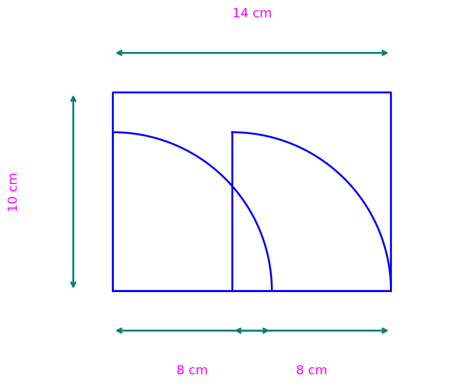

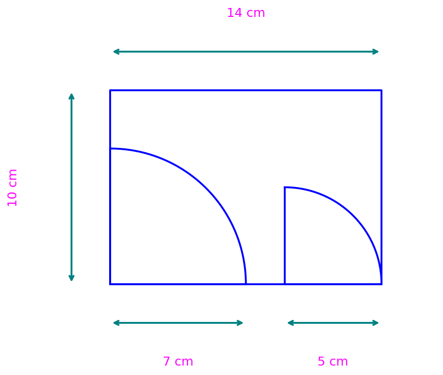

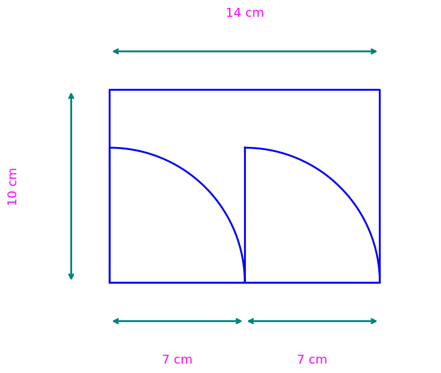

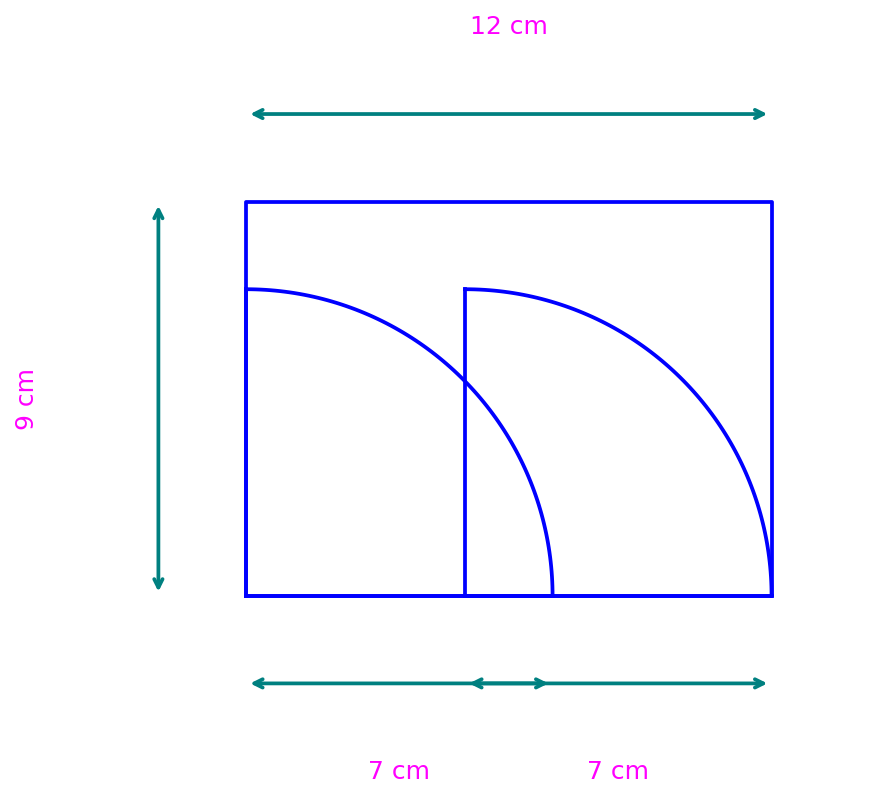

# Solution

Para resolver este problema, debemos analizar correctamente las dimensiones del cristal delantero y las limpiadores de cristals según la información proporcionada:

- El cristal delantero tiene 14 cm de largo y 10 cm de ancho.
- Cuenta con dos limpiadores de cristals de 7 cm de longitud cada una.
- Las limpiadores de cristals tienen un ángulo de apertura de 90°.

La opción correcta debe mostrar: 1. Un rectángulo con dimensiones 14 cm × 10 cm 2. Dos arcos de 7 cm de radio cada uno

Analizando cada opción:

- **Opción A**: Rectángulo: 14 cm × 10 cm. Plumillas: 8 cm y 8 cm. Esta opción es incorrecta porque las dimensiones de las plumillas no coinciden con las especificadas (7 cm cada una). ✗
- **Opción B**: Rectángulo: 14 cm × 10 cm. Plumillas: 7 cm y 5 cm. Esta opción es incorrecta porque las dimensiones de las plumillas no coinciden con las especificadas (7 cm cada una). ✗
- **Opción C**: Rectángulo: 14 cm × 10 cm. Plumillas: 7 cm y 7 cm. Esta opción es correcta porque coincide exactamente con todas las dimensiones descritas en el problema. ✓
- **Opción D**: Rectángulo: 12 cm × 9 cm. Plumillas: 7 cm y 7 cm. Esta opción es incorrecta porque las dimensiones del rectángulo no coinciden con las especificadas (14 cm × 10 cm). ✗

Por lo tanto, la opción correcta es la C.

## Answerlist

- Falso
- Falso
- Verdadero
- Falso

# Meta-information

exname: geometria_limpiaparabrisas_dimensiones extype: schoice exsolution: 0010 exshuffle: TRUE exsection: Geometría|Dimensiones|Medidas extol: 0.01 exextra[html]: